# Descriptive Statistics on Beatles dataset

Karan Pillay

November 15, 2019

```r
d= read.csv('Beatles.csv')
```

## A.

### (A1) Determine the median song length of each album

```r
albumMed = apply(d,2, median, na.rm=T)
albumMed
```

```
##   PPM   WTB   HDN   BFS   HLP   RBS   RVR   SPL   TBS   YSB   ABR   LIB
## 143.0 141.5 140.0 146.5 143.0 148.5 149.5 164.0 174.0 200.5 165.0 200.0
```

### (A2) Construct a bar graph with album name on the horizontal axis and median song length on the vertical axis

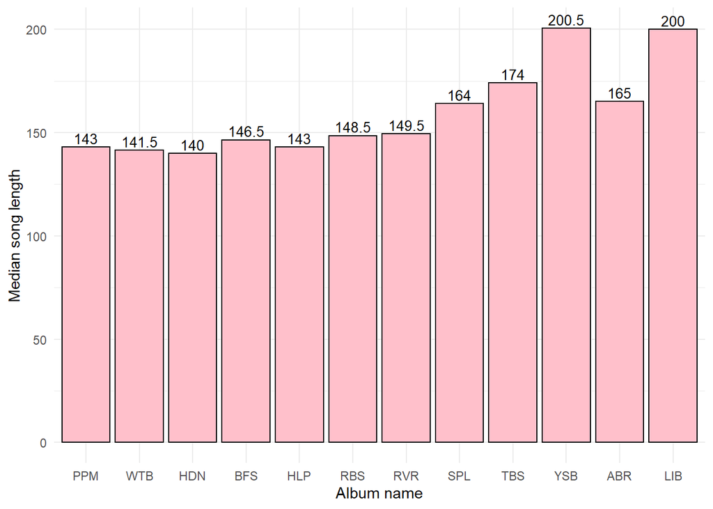

```r
A = data.frame(albumMed)
library(ggplot2)
B = ggplot(data=A, aes(x=row.names(A), y= albumMed)) +
  geom_bar(stat="identity",  color="black", fill="pink") +
  geom_text(aes(label= albumMed), vjust=-0.3, size=3.5) +
  theme_minimal() + scale_x_discrete(limits=row.names(A))
B + labs(x = "Album name", y = "Median song length")
```

### B.

### (B1) Determine the range of song lengths for each album

```r
R =  apply(d, 2, range, na.rm = TRUE)
R = R[2,] - R[1,]
R
```

```
## PPM WTB HDN BFS HLP RBS RVR SPL TBS YSB ABR LIB
##  67  74  57  69  76  77  60 253 441 258 444 200
```

### (B2) Construct a bar graph with album name on the horizontal axis and range of song lengths on the vertical axis

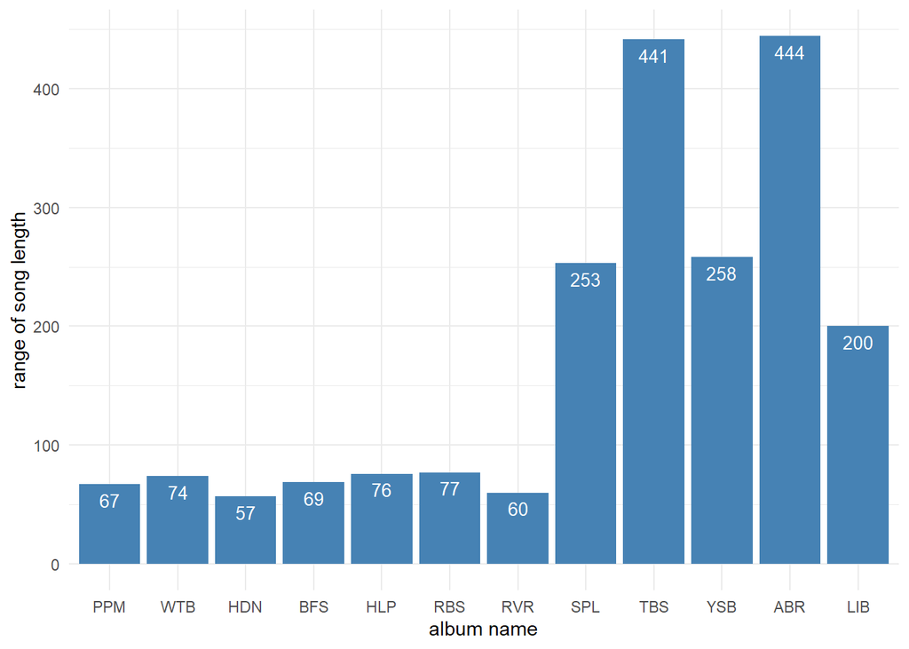

```r
Bar =  data.frame(R)
p = ggplot(data=Bar, aes(x=row.names(Bar), y=R)) +
  geom_bar(stat="identity", fill="steelblue") + geom_text(aes(label=R), vjust=1.6, color="white", size=3.5)+
  theme_minimal() + scale_x_discrete(limits=row.names(Bar))
p + labs(x = "album name", y = "range of song length")
```

### (B3) Interpretation of the graph

As showned above, Abbey Road (ABR) album has the widest range of song length (23~467). In other words, this album contains the biggest difference between the longest and shortest time of song length. Whereas, A Hard Day’s Night (HDN) has narrowest range of song length (109~166) and contributes the smallest difference between the longest and shortest time of song length.

### C.Find the quartiles of song length for each album

```r
quants = c(0.25,0.50,0.75)
AlbumQRT = apply(d, 2, quantile, prob = quants, na.rm = TRUE)
AlbumQRT
```

```
##        PPM    WTB HDN    BFS    HLP    RBS    RVR SPL    TBS   YSB ABR    LIB
## 25% 124.25 128.25 132 125.25 125.75 140.00 130.50 157 145.00 167.0  96 150.25
## 50% 143.00 141.50 140 146.50 143.00 148.50 149.50 164 174.00 200.5 165 200.00
## 75% 151.50 155.00 153 153.00 154.50 162.75 158.75 210 207.75 222.0 207 219.50
```

### D.

### (D1) Determine the IQR of song lengths for each album

```r
AlbumIQR =  apply(d, 2, IQR, na.rm = TRUE)
AlbumIQR
```

```
##    PPM    WTB    HDN    BFS    HLP    RBS    RVR    SPL    TBS    YSB    ABR
##  27.25  26.75  21.00  27.75  28.75  22.75  28.25  53.00  62.75  55.00 111.00
##    LIB
##  69.25
```

### (D2) Construct a bar graph with album name on the horizontal axis and IQR of song lengths on the vertical axis

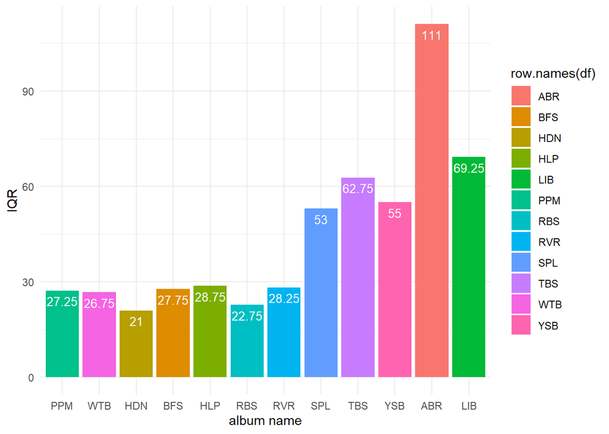

```r
library(ggplot2)
df = data.frame(AlbumIQR)
p= ggplot(df, aes(x=row.names(df), y=AlbumIQR, fill=row.names(df))) +
  geom_bar(stat="identity") + geom_text(aes(label=AlbumIQR), vjust=1.6, color="white", size=3.5) + theme_minimal() +
   scale_x_discrete(limits=row.names(df))
p + labs(x = "album name", y = "IQR")
```

### (D3) Tnterpretation of the graph The bar graph indicates that Abbey Road (ABR) album has the highest IQR of song lengths approximately 111 while A Hard Day’s Night (HDN) album contributes lowest value of IQR of song lengths which is 21.